# Fitting a covariate diffusion model

Author

Max Lindmark, Sean C. Anderson, James Thorson

Published

September 4, 2025

```r
library(tidyr)
library(viridis)
library(patchwork)
library(sf)
library(Matrix)
library(TMB)
library(rnaturalearth)
library(terra)
library(fmesher)
library(ggplot2)
theme_set(theme_light())
library(RCurl)
```

In this vignette, we walk through all the steps to prepare data for a diffusion model within the SPDE framework (Lindgren, Rue & Lindström, 2011; Lindgren 2023), fit it with the R-package TMB (Kristensen et al., 2016), and lastly visualize the diffused covariate. A “diffusion model” here refers to a model where a sparse inverse diffusion operator is applied to covariate(s) to calculate a spatially weighted average of local habitat (Lindmark, Anderson & Thorson, 2025). This vignette is mainly to showcase the workflow; for technical details and derivations, we refer to the paper (Lindmark, Anderson & Thorson, 2025).

### Preparing data and SPDE matricies

First we read trawl data, shapefiles and depth-rasters.

```r
# Set path
home <- here::here()

# Read trawl data from the GitHub repository
cap <- read.csv(
  "https://raw.githubusercontent.com/maxlindmark/covariate_diffusion/refs/heads/paper/data/all_EBS_data_2021.csv"
) |>
  dplyr::select(c(1:14, "cap"))

# Download shapefiles and bathymetry from the repository.
# Read, project & clean them
shape1 <- st_read(paste0(home, "/data/EBSThorson"))
shape2 <- st_read(paste0(home, "/data/NBSThorson"))
domain_shape <- c(st_geometry(shape1), st_geometry(shape2))
bdepth <- rast(paste0(home, "/data/bdepth.tif"))

# Make domain from shapefile
domain_shape <- st_geometry(domain_shape)
domain_shape <- st_cast(domain_shape, to = "POLYGON")
domain_shape <- st_transform(domain_shape, crs = 4326)
domain_shape <- st_make_valid(domain_shape)
```

Now we need to convert sampling locations into an `sf` multipoint object, construct a spatial domain around those locations, and build a prediction-grid and a finite element mesh (FEM) over the domain.

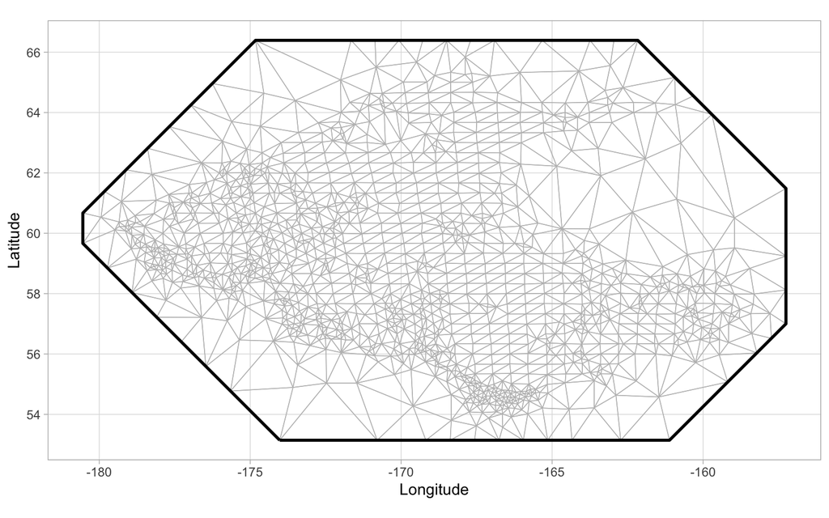

```r
# Convert data locations into an sf object
# Use the same CRS as the depth-raster
loc <- st_multipoint(as.matrix(cap[, c("lon", "lat")]), dim = "XY")
sf_loc <- st_sfc(loc, crs = st_crs(bdepth))
sf_loc <- st_transform(sf_loc, crs = 4326)

# Build a spatial domain from data points
domain <- st_concave_hull(sf_loc, ratio = 0.1)
domain <- st_sfc(domain, crs = st_crs(sf_loc))

# Create an evenly-spaced grid covering the extent of the domain
# Extract centroid of each cell
sf_grid <- st_make_grid(domain_shape, cellsize = c(0.1, 0.1))
sf_grid <- st_intersection(sf_grid, domain_shape)
grid_loc <- st_coordinates(st_centroid(sf_grid))

# Construct a triangular mesh from the point locations
# Cutoff is the minimum triangle edge length
mesh <- fmesher::fm_mesh_2d(st_coordinates(sf_loc)[, 1:2], cutoff = 0.1)

ggplot() +
  geom_fm(data = mesh, fill = NA) +
  labs(x = "Longitude", y = "Latitude")
```

Set up the SPDE objects for spatial modeling.

```r
# Compute finite element matrices for the SPDE approach
spde <- fm_fem(mesh)
# Compute projection matrices from mesh nodes to your data locations
A_is <- fm_evaluator(mesh, loc = st_coordinates(sf_loc))$proj$A
# Compute projection matrices from mesh nodes to your grid locations
A_gs <- fm_evaluator(mesh, loc = grid_loc)$proj$A

invM0 <- invsqrtM0 <- spde$c0
diag(invsqrtM0) <- 1 / sqrt(diag(spde$c0))
diag(invM0) <- 1 / diag(spde$c0)
```

This next and last bit of data preparation is what differs from a standard SPDE model.

In contrast to a standard SPDE-based spatial model, where one has fixed effect covariate values for observations, a diffusion model requires covariate values at all mesh vertices. This is because the inverse-diffusion matrix operates across the entire domain. I.e., the diffusion operator $\mathbf{D}$ needs covariate values $x$ at every mesh vertex to compute the diffused covariate values $\mathbf{Dx}$, which represent the impact of nearby covariates rather than just local values.

```r
# Extract covariate values (depth) to the SPDE mesh nodes.
mesh_points <- sf_project(mesh$loc[, 1:2], from = st_crs(4326), to = st_crs(bdepth))
depth_s <- terra::extract(bdepth, mesh_points)[, 1]
# Fill in missing covariates
depth_s <- ifelse(is.na(depth_s), mean(depth_s, na.rm = TRUE), depth_s)

# For scaling and scaling back covariate
mean_depth_s <- mean(depth_s)
sd_depth_s <- sd(depth_s)
depthprime_s <- (depth_s - mean_depth_s) / sd_depth_s
```

### Fitting the model

We model counts of capelin at each site using a Poisson model with an observation-level random intercept in link space to allow for additional dispersion beyond the 1:1 mean-variance of the Poisson (a lognormal Poisson), and a log link. A quadratic effect of a diffused or the raw covariate is included as a predictor (note the model below can estimate a diffusion model or standard model, depending on what the used supplies in the Data list).

We use R to prepare data and parameters, create the TMB object, and run numerical optimization via `nlminb()`. The objective function, written in C++, defines how parameters and data combine to calculate the negative log-likelihood of our model.

The steps to fitting the model are:

1. Write & compile C++ template
2. Make a list of data objects to pass to TMB
3. Make a list parameters and initial values
4. Create TMB object
5. Optimize model with `nlminb()`

The C++ code we’ll use for this specific model is in the following chunk. As mentioned, it fits either a standard or a diffusion model, depending on what is provided in the `Data` list. The following chunk writes the .cpp file to a folder called “tmb” in your home directory. It is a slightly trimmed down version of the .cpp [files used in the paper](https://github.com/maxlindmark/covariate_diffusion/tree/paper/tmb), which allow for different distributions, simulating from the model, and reporting other output.

```cpp
cpp_code <- '

#include <TMB.hpp>

// Space time
template<class Type>
Type objective_function<Type>::operator() ()
{
  using namespace density;

  // Data
  DATA_STRING(method); // which method to use (e.g., "diffusion")
  DATA_STRING(dist); // distribution (this example uses "LNP" (lognormal-Poisson))
  DATA_VECTOR(c_i);  // counts for observation i
  DATA_VECTOR(weights_i); // weights for calculating cAIC
  DATA_VECTOR(depth_s);  // covariate values at mesh vertices

  // SPDE objects (computed from mesh)
  DATA_SPARSE_MATRIX(M0);
  DATA_SPARSE_MATRIX(M1);
  DATA_SPARSE_MATRIX(M2);
  DATA_SPARSE_MATRIX(invsqrtM0);
  DATA_SPARSE_MATRIX(invM0);

  // Projection matrices from mesh nodes to:
  DATA_SPARSE_MATRIX(A_is); // observation level, i
  DATA_SPARSE_MATRIX(A_gs); // prediction grid, g

  // Parameters
  PARAMETER(beta0); // Intercept
  PARAMETER_VECTOR(beta_j); // depth coefficients (linear + quadratic)
  PARAMETER(ln_tau); // scalar of the precision matrix
  PARAMETER(ln_kappa); // decorrelation rate

  // Random effects
  PARAMETER_VECTOR(omega_s); // spatial random effects

  // Objective function
  Type jnll = 0.0; // joint negative log-likelihood

  // Derived quantities
  // Q = precision matrix for the Gaussian random field
  Eigen::SparseMatrix<Type> Q = (exp(4*ln_kappa)*M0 +
    Type(2.0)*exp(2*ln_kappa)* M1 + M2) * exp(2*ln_tau);
  jnll += GMRF(Q)(omega_s);

  // Probability of random effects (depending on if method is diffusion or not)
  if(method == "diffusion"){
    PARAMETER(ln_kappa2);
    Eigen::SparseLU< Eigen::SparseMatrix<Type>, Eigen::COLAMDOrdering<int> > lu;

    Eigen::SparseMatrix<Type> I_ss( depth_s.size(), depth_s.size() );
    I_ss.setIdentity();
    Eigen::SparseMatrix<Type> invD = I_ss + exp(-2.0 * ln_kappa2) * (invM0 * M1);

    lu.compute(invD);
    REPORT(invD);

    // Solve
    matrix<Type> depth_sz = lu.solve(depth_s.matrix());;

    depth_s = depth_sz.col(0); // turn one column matrix to vector

    // Derived range parameter for diffusion
    Type Range2 = sqrt(8) / exp(ln_kappa2);
    REPORT(Range2);
    REPORT(ln_kappa2);
  }

  // Projection to obs / grid
  vector<Type> depth_i = A_is * depth_s;
  vector<Type> depth_g = A_gs * depth_s;
  REPORT(depth_s);
  REPORT(depth_i);
  REPORT(depth_g);
  vector<Type> omega_i = A_is * omega_s;
  vector<Type> omega_g = A_gs * omega_s;

  // Polynomial depth effect (linear + quadratic terms)
  vector<Type> pdepth_i = depth_i*beta_j(0) + pow(depth_i,2)*beta_j(1);
  vector<Type> pdepth_g = depth_g*beta_j(0) + pow(depth_g,2)*beta_j(1);

  // Expected mean counts at observation locations
  vector<Type> mu_i = exp(beta0 + omega_i + pdepth_i);
  PARAMETER(ln_sigma_eta);
  PARAMETER_VECTOR(eta_i);
  for(int i=0; i<c_i.size(); i++){
    // Using weights here so that we can set them to 0 when calculating conditional AIC
    if (weights_i(i) > Type(0.0)) {
      jnll -= dnorm(eta_i(i), Type(0.0), exp(ln_sigma_eta), true);
      jnll -= dpois(c_i(i), mu_i(i) * exp(eta_i(i)), true);
    }
  }

  // Expected mean counts at prediction grid
  vector<Type> mu_g = exp(beta0 + omega_g + pdepth_g);

  // Reporting (output)
  REPORT(Q);
  REPORT(mu_i); // predicted counts at observations
  REPORT(mu_g); // predicted counts at grid level
  REPORT(pdepth_i);
  REPORT(pdepth_g);

  return jnll;
}'

writeLines(cpp_code, paste0(home, "/tmb/movement_kernel_vignette.cpp"))
```

Once the file is written, we compile it.

```r
# Compile and load
setwd(home) # This is needed if you have spaces in your path!
TMB::compile("tmb/movement_kernel_vignette.cpp", framework = "TMBad")
```

```
using C++ compiler: 'Apple clang version 17.0.0 (clang-1700.0.13.3)'
```

```
using SDK: 'MacOSX15.4.sdk'
```

```
[1] 0
```

```r
dyn.load(dynlib("tmb/movement_kernel_vignette"))
```

Next we define a list of data objects to pass to TMB.

```r
Data <- list(
  "method" = "diffusion", # Use diffusion approach (see .cpp file)
  "dist" = "LNP", # Lognormal Poisson
  "c_i" = cap[, "cap"], # Counts of capelin
  "weights_i" = rep(1, times = nrow(cap)), # For conditional AIC calculations
  "A_is" = A_is, # Projection matrix (mesh to observations)
  "A_gs" = A_gs, # Projection matrix (mesh to grid)
  "M0" = spde$c0, # SPDE matrix
  "M1" = spde$g1, # SPDE matrix
  "M2" = spde$g2, # SPDE matrix
  "invsqrtM0" = invsqrtM0, # Inverse matrix
  "invM0" = invM0, # Inverse matrix
  "depth_s" = depthprime_s, # Depth values at mesh vertices
  "sim_gmrf" = 0L
)
```

And a list of parameters and their starting values.

```r
Params <- list(
  "beta0" = 0, # Intercept
  "beta_j" = c(0.1, 0.1), # Coefficient for diffused depth effect (recall a quadratic effect)
  "ln_tau" = 0, # Scalar of the precision matrix
  "ln_kappa" = 0, # De-correlation rate
  "omega_s" = rnorm(nrow(spde$c0)), # Spatial random effects (estimated at mesh vertices)
  "ln_kappa2" = exp(-1) # Strength of the covariate diffusion
)

Params$ln_sigma_eta <- log(0.1)
Params$eta_i <- rnorm(nrow(cap))
Random <- c("omega_s", "eta_i")
```

Create the TMB object (containing functions to calculate the objective function and its gradient).

```r
Obj <- MakeADFun(
  data = Data,
  parameters = Params,
  random = Random,
  checkParameterOrder = TRUE
)
# Obj$env$beSilent()
```

And use `nlminb()` to optimize parameters.

```r
# Optimize
Opt <- nlminb(
  start = Obj$par,
  obj = Obj$fn,
  grad = Obj$gr,
  control = list(eval.max = 1e4, iter.max = 1e4, trace = 1)
)
Report <- Obj$report()
```

### Visualizing model output

We can check our optimized parameters and their standard errors.

```r
# Check parameter estimates
Opt$par
```

```
       beta0       beta_j       beta_j       ln_tau     ln_kappa    ln_kappa2
  -8.7248954  -16.3046957   18.2461501   -1.2976628   -1.0243468   -0.6299777
ln_sigma_eta
   0.9558338
```

```r
# To view standard errors, run this (commented out because it is very slow)
# sdreport(Obj)
```

Lastly, we can visualize predictions and the diffused covariate spatially.

First make a little base map.

```r
map_data <- rnaturalearth::ne_countries(
  scale = "medium",
  returnclass = "sf", continent = "North America"
)

alaska <- suppressWarnings(suppressMessages(
  st_crop(
    map_data,
    c(xmin = -179, ymin = 50, xmax = -150, ymax = 70)
  )
))

map_ebs <- ggplot(alaska) +
  geom_sf(linewidth = 0.4, color = "gray40") +
  coord_sf(expand = FALSE) +
  xlim(-178, -155) +
  ylim(53, 66) +
  labs(x = "Longitude", y = "Latitude") +
  theme(
    legend.key.width = unit(0.4, "cm"),
    legend.key.height = unit(0.2, "cm"),
    legend.direction = "horizontal",
    legend.position.inside = c(0.86, 0.92),
    legend.background = element_blank()
  ) +
  guides(
    fill = guide_colorbar(title.position = "top",
                          title.hjust = 0.5, position = "inside")
  ) +
  scale_fill_viridis(
    option = "mako", na.value = NA, direction = -1,
    breaks = scales::pretty_breaks(n = 2), name = "Depth",
  ) +
  annotate("text", label = "Bering\nSea", x = -177, y = 65,
           color = "gray50", size = 2.8)
```

Next gather predictions in a sf data frame.

```r
stuff_gz <- st_sf(sf_grid,
  "original" = as.vector(Data$A_gs %*% Data$depth_s),
  "diffused" = Report$depth_g
  )
```

Below we see how the diffused covariate is “smeared” out in space, with the total covariate “mass” conserved.

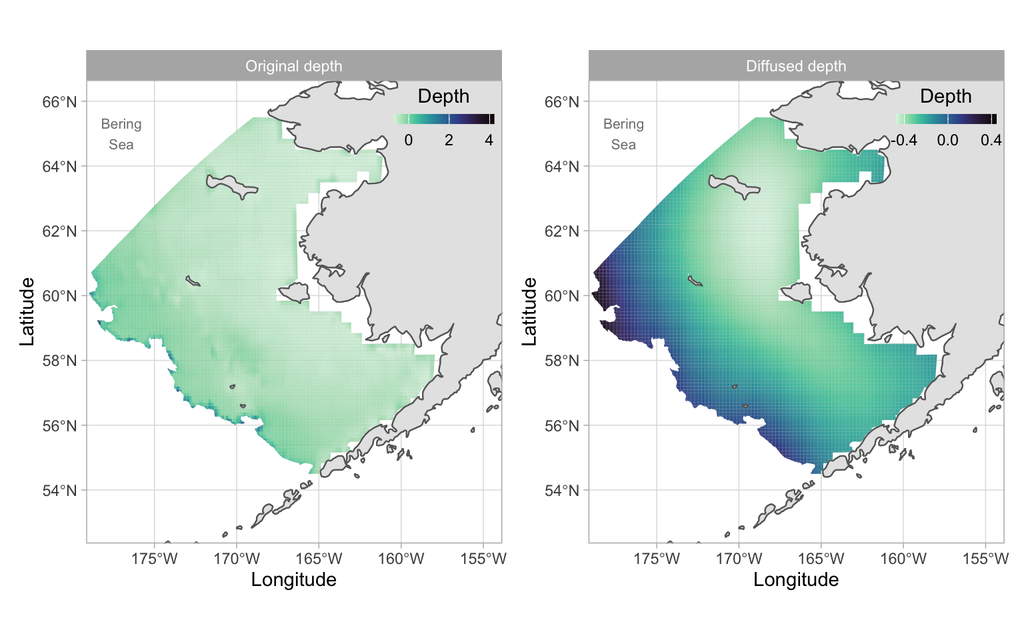

```r
p1 <- map_ebs +
  geom_sf(data = stuff_gz, aes(fill = original), linewidth = 0.01) +
  geom_sf(linewidth = 0.4, color = "gray40") +
  facet_wrap(~"Original depth")

p2 <- map_ebs +
  geom_sf(data = stuff_gz, aes(fill = diffused), linewidth = 0.01) +
  geom_sf(linewidth = 0.4, color = "gray40") +
  facet_wrap(~"Diffused depth") +
  scale_fill_viridis(
    option = "mako", na.value = NA, direction = -1,
    breaks = c(-0.4, 0, 0.4), name = "Depth",
  )

(p1 + p2) & plot_layout(axis_titles = "collect_y", axes = "collect_y")
```

The code to generate this vignette is found here: https://github.com/maxlindmark/covariate_diffusion/blob/paper/docs/index.qmd

## References

Kristensen, K., Nielsen, A., Berg, C. W., Skaug, H., & Bell, B. M. (2016). TMB: Automatic Differentiation and Laplace Approximation. Journal of Statistical Software, 70(1), Article 1. https://doi.org/10.18637/jss.v070.i05

Lindgren, F. (2023). *fmesher: Triangle Meshes and Related Geometry Tools*. R package version 0.1.5, https://CRAN.R-project.org/package=fmesher.

Lindgren, F., Rue, H., & Lindström, J. (2011). An explicit link between Gaussian fields and Gaussian Markov random fields: The stochastic partial differential equation approach. Journal of the Royal Statistical Society: Series B (Statistical Methodology), 73(4), 423–498. https://doi.org/10.1111/j.1467-9868.2011.00777.x

Lindmark, M., Anderson, S. C., & Thorson, J. T. (2025). Estimating scale-dependent covariate responses using two-dimensional diffusion derived from the SPDE method (p. 2024.12.17.628864). bioRxiv. https://doi.org/10.1101/2024.12.17.628864